# Day-03. Shape Statistics I

PCA, PLS, PACA

## **Content Description**

In `geomorph`, several functions allow analysis of shape covariation with other matrices, which contain data or parameters. The table below indicate functions that are frequently used, plus what the types of analysis they tend to perform.

| Function | Alignment | Notes |
| --- | --- | --- |
| `gm.prcomp` | Identity matrix or phylogenetic covariance matrix | This function is a wrapper for the `RRPP::ordinate` function, which allows alignment to any kind of matrix. `gm.prcomp` only aligns data to an identity matrix (PCA) or phylogenetic covariance matrix (… |
| `two.b.pls` | Any alternative matrix | This is a basic function that allows any two data matrices (or vectors) to be input, but a covariance matrix or matrix of model parameters could also be used. |
| `integration.test` | A portion of shape data | This is basically the same as `two.b.pls` used for comparison of two subsets of shape data. It will perform the partitioning of data. **This function is deferred to the module on integration and modul… |
| `phylo.integration` | A portion of shape data | This is basically the same as `integration.test` but transforms data based on phylogenetic covariances. **This function is deferred to the module on integration and modularity.** |

### Set up

```r
library(geomorph)
```

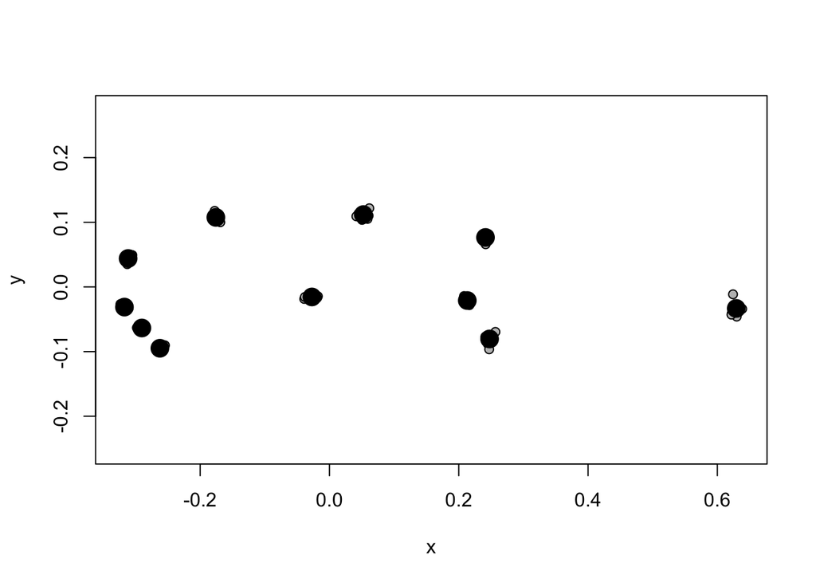

```r
data(plethspecies)
Y.gpa <- gpagen(plethspecies$land, print.progress = FALSE)
plot(Y.gpa)
```

# Principal component analysis (PCA)

PCA is the same as an alignment of data to an identity matrix (independence). This is an unconstrained alignment. SVD finds principal components (eigenvectors) and singular values that can be transformed into eigenvalues. In `gm.prcomp`, the set-up is pretty straightforward.

```r
PCA <- gm.prcomp(Y.gpa$coords, phy = plethspecies$phy,
                 align.to.phy = FALSE,
                 GLS = FALSE)
```

A summary will provide basic information about the strength of components.

```r
summary(PCA)
```

```
##
## Ordination type: Principal Component Analysis
## Centering by OLS mean
## Orthogonal projection of OLS residuals
## Number of observations: 9
## Number of vectors 8
##
## Importance of Components:
##                               Comp1        Comp2        Comp3        Comp4
## Eigenvalues            0.0002720474 0.0001120524 0.0001084758 0.0000568924
## Proportion of Variance 0.4564029477 0.1879858086 0.1819855633 0.0954461044
## Cumulative Proportion  0.4564029477 0.6443887563 0.8263743196 0.9218204240
##                               Comp5        Comp6        Comp7        Comp8
## Eigenvalues            0.0000264508 1.260516e-05 5.959622e-06 1.584785e-06
## Proportion of Variance 0.0443754550 2.114717e-02 9.998220e-03 2.658730e-03
## Cumulative Proportion  0.9661958790 9.873431e-01 9.973413e-01 1.000000e+00
##
##
## Dispersion (variance) of points, after projection:
##                                        Comp1        Comp2        Comp3
## Tips Dispersion                 2.720474e-04 1.120524e-04 1.084758e-04
## Proportion Tips Dispersion      4.564029e-01 1.879858e-01 1.819856e-01
## Cumulative Tips Dispersion      4.564029e-01 6.443888e-01 8.263743e-01
## Ancestors Dispersion            3.073342e-05 2.320038e-05 2.039005e-05
## Proportion Ancestors Dispersion 3.854327e-01 2.909597e-01 2.557149e-01
## Cumulative Ancestors Dispersion 3.854327e-01 6.763923e-01 9.321072e-01
##                                        Comp4        Comp5        Comp6
## Tips Dispersion                 5.689240e-05 2.645080e-05 1.260516e-05
## Proportion Tips Dispersion      9.544610e-02 4.437545e-02 2.114717e-02
## Cumulative Tips Dispersion      9.218204e-01 9.661959e-01 9.873431e-01
## Ancestors Dispersion            3.171758e-06 1.748508e-06 3.945777e-07
## Proportion Ancestors Dispersion 3.977752e-02 2.192831e-02 4.948462e-03
## Cumulative Ancestors Dispersion 9.718847e-01 9.938130e-01 9.987615e-01
##                                        Comp7        Comp8
## Tips Dispersion                 5.959622e-06 1.584785e-06
## Proportion Tips Dispersion      9.998220e-03 2.658730e-03
## Cumulative Tips Dispersion      9.973413e-01 1.000000e+00
## Ancestors Dispersion            8.354868e-08 1.520561e-08
## Proportion Ancestors Dispersion 1.047797e-03 1.906960e-04
## Cumulative Ancestors Dispersion 9.998093e-01 1.000000e+00
```

The loadings are found in the rotation matrix.

```r
PCA$rot
```

```
##              Comp1        Comp2        Comp3        Comp4        Comp5
## 1.X   0.0639937781  0.205429539  0.170984900  0.092240499 -0.243267662
## 1.Y  -0.2186270977 -0.001301379  0.016212731  0.203187307  0.232599624
## 2.X  -0.0878606406  0.319081044  0.248024539 -0.043348223 -0.422003358
## 2.Y  -0.4476470091  0.217392614  0.039671153 -0.203712850  0.192957190
## 3.X  -0.1019656118 -0.110250492  0.609109959 -0.431680823  0.150168617
## 3.Y  -0.0771373917 -0.000805622 -0.029967224 -0.137763592  0.268182949
## 4.X   0.1992343645  0.151262835 -0.039895153  0.185626140  0.194435236
## 4.Y   0.1213302225  0.209895468  0.057399404  0.251871724  0.111182304
## 5.X  -0.1842674107 -0.032308565 -0.090353311 -0.072747314  0.034807610
## 5.Y   0.0425135453  0.254311461 -0.063056292 -0.001214202  0.019992286
## 6.X  -0.0220413670 -0.295845336 -0.234744294 -0.022580385 -0.150555325
## 6.Y   0.0736696008  0.279725523 -0.052761729  0.001311960 -0.006695822
## 7.X   0.0243393890 -0.141536784 -0.254900654 -0.110273929 -0.221595979
## 7.Y   0.1658520151 -0.303306114 -0.036556119 -0.243396155 -0.146444364
## 8.X  -0.0368710126  0.217236787 -0.156732264 -0.107859034  0.040626986
## 8.Y   0.2086654440 -0.239063444  0.137631794 -0.187091618 -0.188967129
## 9.X   0.1213972184 -0.346758562  0.329744837  0.506442373  0.331171499
## 9.Y  -0.2372316829 -0.347693604  0.022022217  0.078551200 -0.083188623
## 10.X  0.0250307386  0.120458956 -0.110704841  0.209168061 -0.046515607
## 10.Y -0.2712050629 -0.124605602 -0.088814356  0.346012061 -0.406222454
## 11.X -0.0009894458 -0.086769422 -0.470533717 -0.204987364  0.332727983
## 11.Y  0.6398174166  0.055450698 -0.001781577 -0.107755835  0.006604039
##             Comp6        Comp7        Comp8
## 1.X  -0.057696809 -0.082018500 -0.303542573
## 1.Y  -0.120021863  0.276412995 -0.077892129
## 2.X  -0.280884684  0.258233252 -0.072700886
## 2.Y  -0.399470856  0.013087244  0.213232472
## 3.X   0.266994201 -0.229702388  0.273994933
## 3.Y   0.173409908 -0.080136106 -0.428624862
## 4.X   0.193960296  0.364404309  0.028518481
## 4.Y  -0.060369636 -0.007322196  0.137180098
## 5.X   0.105224695 -0.120514442 -0.610922851
## 5.Y   0.054936387 -0.188788073  0.047714415
## 6.X  -0.059997340  0.188172920  0.306580312
## 6.Y   0.046173917 -0.210147221  0.085048928
## 7.X  -0.267197382 -0.358079748 -0.000149742
## 7.Y  -0.400044714  0.168529291 -0.087173774
## 8.X   0.230143705  0.202353581  0.192887205
## 8.Y   0.263157045  0.234209239 -0.041482088
## 9.X  -0.285451487 -0.183496405  0.011214603
## 9.Y   0.193990843  0.278003063 -0.046542405
## 10.X  0.160016458  0.070132402  0.078512706
## 10.Y  0.285586293 -0.366237418  0.176914090
## 11.X -0.005111653 -0.109484980  0.095607812
## 11.Y -0.037347324 -0.117610818  0.021625255
```

Centered data are inherently projected onto PCs, which can be plotted as scores.

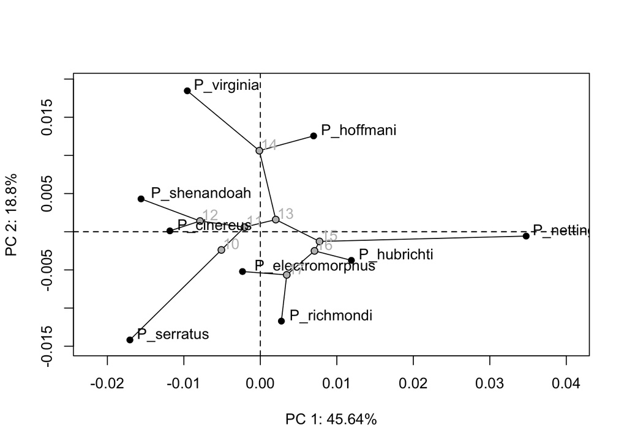

```r
PCAplot <- plot(PCA, pch = 16, phylo = TRUE)
```

This can be done for interactive plotting:

```r
# Explore shape change in the plot
picknplot.shape(PCAplot)
picknplot.shape(PCAplot, mag = 3)
```

In case one wishes to use results for other reasons:

```r
attributes(PCA)
```

```
## $names
##  [1] "d"         "sdev"      "rotation"  "center"    "scale"     "GLS"
##  [7] "transform" "alignment" "RV"        "x"         "A"         "shapes"
## [13] "ancestors" "phy"       "anc.x"     "anc.var"
##
## $class
## [1] "gm.prcomp" "ordinate"
```

Note that the result provide `d`, not “eigenvalues”. These are the singular values, which `gm.prcomp` transforms to eigenvalues. This is verified below.

```r
PCA$d
```

```
##        Comp1        Comp2        Comp3        Comp4        Comp5        Comp6
## 2.720474e-04 1.120524e-04 1.084758e-04 5.689240e-05 2.645080e-05 1.260516e-05
##        Comp7        Comp8
## 5.959622e-06 1.584785e-06
```

```r
eigen(var(PCA$x), only.values = TRUE)$values
```

```
## [1] 2.720474e-04 1.120524e-04 1.084758e-04 5.689240e-05 2.645080e-05
## [6] 1.260516e-05 5.959622e-06 1.584785e-06
```

Note also that some results won’t be available, e.g.,

```r
PCA$RV
```

# Phylogenetically aligned component analysis (PACA)

PACA aligned data with a phylogenetic covariance matrix rather than an identity matrix.

```r
PACA <- gm.prcomp(Y.gpa$coords, phy = plethspecies$phy,
                 align.to.phy = TRUE,
                 GLS = FALSE)
summary(PACA)
```

```
##
## Ordination type: Alignment to an alternative matrix
## Alignment matrix: phy
## Centering by OLS mean
## OLS residuals
## Alignment to  phy means residual projection is not orthogonal.
## Number of observations: 9
## Number of vectors 8
##
## Importance of Components:
##                                 Comp1        Comp2        Comp3        Comp4
## Singular Value           0.0003931629 0.0001155198 5.091258e-05 2.660786e-05
## Proportion of Covariance 0.6595936040 0.1938028696 8.541399e-02 4.463894e-02
## Cumulative Proportion    0.6595936040 0.8533964737 9.388105e-01 9.834494e-01
## RV by Component          0.0993211764 0.0291827102 1.286158e-02 6.721702e-03
## Cumulative RV            0.0993211764 0.1285038867 1.413655e-01 1.480872e-01
##                                 Comp5        Comp6        Comp7        Comp8
## Singular Value           6.598675e-06 2.351469e-06 7.108871e-07 2.042572e-07
## Proportion of Covariance 1.107033e-02 3.944966e-03 1.192627e-03 3.426742e-04
## Cumulative Proportion    9.945197e-01 9.984647e-01 9.996573e-01 1.000000e+00
## RV by Component          1.666963e-03 5.940304e-04 1.795850e-04 5.159965e-05
## Cumulative RV            1.497541e-01 1.503482e-01 1.505278e-01 1.505794e-01
##
##
## Dispersion (variance) of points, after projection:
##                                        Comp1        Comp2        Comp3
## Tips Dispersion                 2.301865e-04 1.124810e-04 1.133102e-04
## Proportion Tips Dispersion      3.861747e-01 1.887049e-01 1.900960e-01
## Cumulative Tips Dispersion      3.861747e-01 5.748795e-01 7.649755e-01
## Ancestors Dispersion            4.069158e-05 2.437196e-05 8.067595e-06
## Proportion Ancestors Dispersion 5.103196e-01 3.056526e-01 1.011770e-01
## Cumulative Ancestors Dispersion 5.103196e-01 8.159722e-01 9.171492e-01
##                                        Comp4        Comp5        Comp6
## Tips Dispersion                 7.526878e-05 4.046474e-05 1.571235e-05
## Proportion Tips Dispersion      1.262754e-01 6.788606e-02 2.635999e-02
## Cumulative Tips Dispersion      8.912509e-01 9.591370e-01 9.854970e-01
## Ancestors Dispersion            6.244464e-06 3.539330e-07 3.508799e-09
## Proportion Ancestors Dispersion 7.831282e-02 4.438730e-03 4.400441e-05
## Cumulative Ancestors Dispersion 9.954620e-01 9.999008e-01 9.999448e-01
##                                        Comp7        Comp8
## Tips Dispersion                 6.396433e-06 2.248360e-06
## Proportion Tips Dispersion      1.073104e-02 3.771984e-03
## Cumulative Tips Dispersion      9.962280e-01 1.000000e+00
## Ancestors Dispersion            2.594059e-09 1.810230e-09
## Proportion Ancestors Dispersion 3.253251e-05 2.270238e-05
## Cumulative Ancestors Dispersion 9.999773e-01 1.000000e+00
```

In the summary above, the dispersion statistics can be compared to PCA. It should be clear that the tips dispersion (which for PCA is the same as portion of eigenvalue sum) is larger for PCA but the dispersion of estimate ancestral values is large for PACA, in the first component.

Some other typical steps:

```r
PACA$rot # loadings
```

```
##            Comp1        Comp2        Comp3       Comp4        Comp5       Comp6
## 1.X   0.02817716 -0.238265109  0.215048829 -0.02421074 -0.228692597  0.08795239
## 1.Y  -0.24529137  0.031301382 -0.162045684 -0.17684791 -0.044540749 -0.18288472
## 2.X  -0.07608018 -0.402254103  0.336789063  0.19554593 -0.311415307 -0.08246873
## 2.Y  -0.34291440 -0.281460733 -0.146787704  0.21637801  0.084164259 -0.48632474
## 3.X  -0.33515549 -0.041319928  0.452877791  0.02352182  0.579512548  0.07341471
## 3.Y  -0.06807174  0.005443062 -0.137747673 -0.02648898  0.284838026  0.07828795
## 4.X   0.15491526 -0.050339744 -0.103594409 -0.34842667  0.090954174  0.09545823
## 4.Y   0.06978562 -0.153768894 -0.031041240 -0.30836707 -0.099774563 -0.10096432
## 5.X  -0.12222934  0.009775925 -0.132847431  0.12270876  0.042970238  0.15119942
## 5.Y   0.10107867 -0.235599520 -0.098219958 -0.04432624  0.019464133  0.03585376
## 6.X   0.05513603  0.308734201 -0.084911436  0.21393490 -0.107816816 -0.01237432
## 6.Y   0.13049059 -0.261295075 -0.074160763 -0.04790042  0.002664178  0.03473008
## 7.X   0.16449200  0.120453856 -0.054584199  0.34610719 -0.214642033 -0.13112828
## 7.Y   0.18035661  0.274492447  0.235970876  0.32103443 -0.074492678 -0.29994426
## 8.X   0.06637459 -0.184563521 -0.191204043  0.02958695  0.173654346  0.15515196
## 8.Y   0.11342100  0.207464913  0.308225727  0.09008401  0.153482781  0.29553566
## 9.X  -0.17773034  0.383705890  0.163897772 -0.55254176 -0.180155187 -0.35938197
## 9.Y  -0.28554076  0.317790294 -0.006977614  0.05807331 -0.026819790  0.22237835
## 10.X  0.05435288 -0.069410013 -0.141427053 -0.14695228 -0.114758671  0.17491248
## 10.Y -0.23673443  0.085315124 -0.119121918  0.04578262 -0.397601899  0.45339079
## 11.X  0.18774743  0.163482545 -0.460044884  0.14072590  0.270389306 -0.15273588
## 11.Y  0.58342020  0.010317000  0.231905951 -0.12742175  0.098616303 -0.05005855
##            Comp7       Comp8
## 1.X  -0.13731582  0.24925071
## 1.Y   0.23959689  0.16972804
## 2.X   0.25723193  0.11256032
## 2.Y   0.06242302 -0.14317967
## 3.X  -0.19783219 -0.31865053
## 3.Y  -0.19059834  0.41235048
## 4.X   0.35704236  0.06421034
## 4.Y   0.02497692 -0.12266972
## 5.X  -0.25589244  0.55727765
## 5.Y  -0.15758814 -0.08922005
## 6.X   0.26036117 -0.26151817
## 6.Y  -0.16793832 -0.13235333
## 7.X  -0.33359784 -0.08712275
## 7.Y   0.12574723  0.14005208
## 8.X   0.26009832 -0.14048572
## 8.Y   0.20718122  0.05767784
## 9.X  -0.22801585 -0.02371599
## 9.Y   0.25457671  0.08308760
## 10.X  0.10416734 -0.07753820
## 10.Y -0.27561189 -0.33087067
## 11.X -0.08624698 -0.07426765
## 11.Y -0.12276531 -0.04460261
```

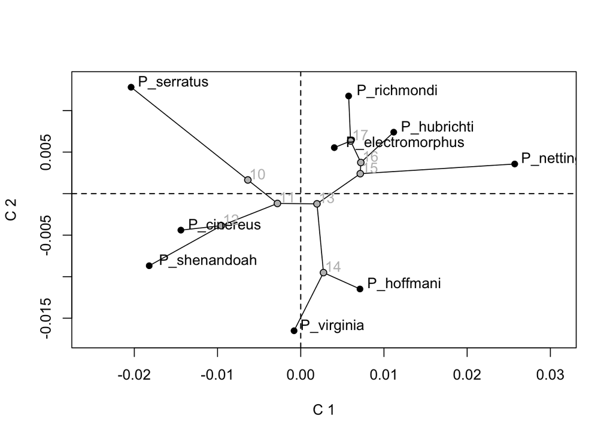

```r
PACAplot <- plot(PACA, pch = 16, phylo = TRUE)
```

And how to do interactive plotting:

```r
# Explore shape change in the plot
picknplot.shape(PACAplot)
picknplot.shape(PACAplot, mag = 3)
```

# phylo-PCA

Phylo-PCA is a little interesting in that it aligns data to an identity matrix that has been transformed. The data are transformed for alignment but not projection. Therefore, the ordination looks like a rotation of the data space, specifically to minimize alignment to phylogeny in the first component.

```r
pPCA <- gm.prcomp(Y.gpa$coords, phy = plethspecies$phy,
                  align.to.phy = FALSE,
                  GLS = TRUE)
summary(pPCA)
```

```
##
## Ordination type: Principal Component Analysis
## Centering by GLS mean
## Oblique projection of GLS-centered residuals
## Number of observations: 9
## Number of vectors 8
##
## Importance of Components:
##                               Comp1        Comp2        Comp3        Comp4
## Eigenvalues            2.761405e-05 9.322868e-06 7.889847e-06 6.605120e-06
## Proportion of Variance 4.855705e-01 1.639351e-01 1.387365e-01 1.161457e-01
## Cumulative Proportion  4.855705e-01 6.495056e-01 7.882421e-01 9.043878e-01
##                               Comp5        Comp6        Comp7        Comp8
## Eigenvalues            3.017886e-06 1.203779e-06 9.895110e-07 2.262231e-07
## Proportion of Variance 5.306707e-02 2.116747e-02 1.739975e-02 3.977950e-03
## Cumulative Proportion  9.574548e-01 9.786223e-01 9.960221e-01 1.000000e+00
##
##
## Dispersion (variance) of points, after projection:
##                                        Comp1        Comp2        Comp3
## Tips Dispersion                 0.0002498092 8.395185e-05 1.057114e-04
## Proportion Tips Dispersion      0.4190949497 1.408427e-01 1.773479e-01
## Cumulative Tips Dispersion      0.4190949497 5.599376e-01 7.372855e-01
## Ancestors Dispersion            0.0000169982 9.862682e-06 2.194379e-05
## Proportion Ancestors Dispersion 0.2131770701 1.236895e-01 2.752006e-01
## Cumulative Ancestors Dispersion 0.2131770701 3.368665e-01 6.120671e-01
##                                        Comp4        Comp5        Comp6
## Tips Dispersion                 0.0001027383 2.765308e-05 1.675548e-05
## Proportion Tips Dispersion      0.1723598707 4.639247e-02 2.811000e-02
## Cumulative Tips Dispersion      0.9096453329 9.560378e-01 9.841478e-01
## Ancestors Dispersion            0.0000272722 1.114653e-06 1.772175e-06
## Proportion Ancestors Dispersion 0.3420249711 1.397905e-02 2.222513e-02
## Cumulative Ancestors Dispersion 0.9540920945 9.680711e-01 9.902963e-01
##                                        Comp7        Comp8
## Tips Dispersion                 7.598972e-06 1.850019e-06
## Proportion Tips Dispersion      1.274849e-02 3.103703e-03
## Cumulative Tips Dispersion      9.968963e-01 1.000000e+00
## Ancestors Dispersion            7.068511e-07 6.689930e-08
## Proportion Ancestors Dispersion 8.864732e-03 8.389947e-04
## Cumulative Ancestors Dispersion 9.991610e-01 1.000000e+00
```

```r
pPCA$rot # loadings
```

```
##            Comp1       Comp2       Comp3       Comp4       Comp5       Comp6
## 1.X   0.09744783 -0.10546858  0.15935634  0.20253521  0.16056595 -0.13417564
## 1.Y  -0.19346734 -0.04546925  0.04748510  0.13314937 -0.31958879  0.03820919
## 2.X  -0.04615034 -0.01456001  0.31788816  0.24860337  0.26929078 -0.43940392
## 2.Y  -0.40632562  0.26238469  0.31692917  0.02623064 -0.25583030 -0.28523047
## 3.X   0.14597215  0.71972058  0.06953146  0.24024316  0.17047213  0.24372366
## 3.Y  -0.06286199  0.16702865  0.06292780 -0.13230253 -0.13204067  0.28321955
## 4.X   0.16761177 -0.22087601  0.15606275 -0.03986716 -0.10015865  0.26602236
## 4.Y   0.13108628 -0.21833246  0.17681955  0.13826261 -0.15014233  0.01532702
## 5.X  -0.19670169  0.07135323 -0.02646040 -0.07427358 -0.01608575  0.14216395
## 5.Y   0.01355821 -0.10497217  0.20863595 -0.05094787  0.04326775  0.05069676
## 6.X  -0.10559484 -0.05400958 -0.32560160 -0.16347722  0.07146225 -0.14028781
## 6.Y   0.04410573 -0.12131037  0.22569511 -0.04351735  0.06775454  0.02775797
## 7.X  -0.06720180 -0.04258799 -0.21825539 -0.19852916  0.05832446 -0.34749618
## 7.Y   0.13500781  0.18471676 -0.23605774 -0.19167470 -0.03912350 -0.45136637
## 8.X  -0.10092950 -0.06141568  0.21025616 -0.18671570  0.13523279  0.19077450
## 8.Y   0.23777203  0.17149286 -0.19692014 -0.05050884  0.31388103  0.11569923
## 9.X   0.27018273 -0.04004122 -0.31088594  0.46053345 -0.56988636 -0.03080956
## 9.Y  -0.20846592  0.07202673 -0.32992374  0.11684234  0.08257919  0.15881552
## 10.X -0.02381856 -0.27073567  0.04193546  0.02814845  0.06627038  0.13878284
## 10.Y -0.28627926 -0.29458074 -0.32249372  0.28897650  0.35190153  0.12142179
## 11.X -0.14081777  0.01862092 -0.07382701 -0.51720082 -0.24548798  0.11070581
## 11.Y  0.59587007 -0.07298470  0.04690267 -0.23451016  0.03734153 -0.07455021
##            Comp7       Comp8
## 1.X   0.06289659  0.33262394
## 1.Y  -0.27563621  0.03568874
## 2.X  -0.24701380  0.10036333
## 2.Y   0.04160660 -0.22260700
## 3.X   0.20746529 -0.26120406
## 3.Y   0.05878198  0.40440622
## 4.X  -0.34342055 -0.07804298
## 4.Y   0.03274855 -0.14596129
## 5.X   0.08042809  0.60954976
## 5.Y   0.22058268 -0.03698628
## 6.X  -0.18360502 -0.30657027
## 6.Y   0.24559786 -0.06969995
## 7.X   0.35579585  0.04852852
## 7.Y  -0.19590089  0.09546411
## 8.X  -0.15320117 -0.21525919
## 8.Y  -0.27444452  0.04088870
## 9.X   0.12476439 -0.02278488
## 9.Y  -0.32210796  0.02977825
## 10.X -0.05280724 -0.08448917
## 10.Y  0.34576123 -0.11968177
## 11.X  0.14869758 -0.12271501
## 11.Y  0.12301067 -0.01128974
```

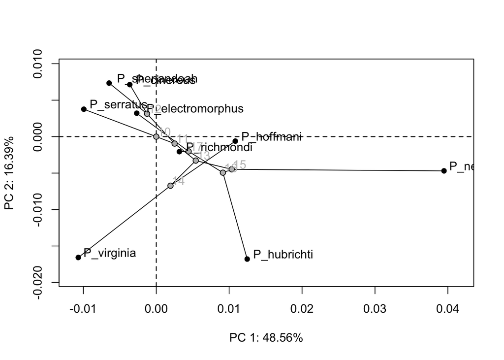

```r
pPCAplot <- plot(pPCA, pch = 16, phylo = TRUE)
```

Notice the difference in dispersion of ancestral points in the summary above, compared to PACA. Interactive plotting can be done as follows:

```r
# Explore shape change in the plot
picknplot.shape(pPCAplot)
picknplot.shape(pPCAplot, mag = 3)
```

**To summarize**: PCA, performed with OLS estimation and no adjustment for phylogeny, find the maximum dispersion of tip taxa along the first component. PACA finds the maximum dispersion of ancestor values along the first component. pPCA finds a first component most independent of phylogeny.

# Partial least-squares (PLS)

PLS aligns shape data or a portion of it to alternative data sets, or alternative portions of the data. We will consider three examples, with the `plethShapeFood` example data.

```r
data("plethShapeFood")
Y.gpa <- gpagen(plethShapeFood$land,
                print.progress = FALSE,)
food <- plethShapeFood$food
rownames(food) <- names(Y.gpa$Csize) # just to assure match

PLSfood <- two.b.pls(food, Y.gpa$coords,
                     print.progress = FALSE,
                     iter = 9999)
PLSallometry <- two.b.pls(Y.gpa$Csize, Y.gpa$coords,
                          print.progress = FALSE,
                          iter = 9999)
PLSintegration <- two.b.pls(Y.gpa$coords[1:5,, ],
                            Y.gpa$coords[8:13,,],
                            print.progress = FALSE,
                            iter = 9999)
```

It is a good idea to look at the results that are available, at least using one example:

```r
attributes(PLSfood)
```

```
## $names
##  [1] "r.pls"             "P.value"           "Z"
##  [4] "left.pls.vectors"  "right.pls.vectors" "random.r"
##  [7] "XScores"           "YScores"           "svd"
## [10] "A1"                "A2"                "A1.matrix"
## [13] "A2.matrix"         "permutations"      "call"
## [16] "method"
##
## $class
## [1] "pls"
```

Loadings:

```r
PLSfood$left.pls.vectors
```

```
##                 [,1]         [,2]        [,3]         [,4]          [,5]
## oligoch   0.09004086  0.003112899  0.10080188  0.409722018  0.0582768813
## gastrop  -0.01806988 -0.550910355 -0.34547832 -0.241358177 -0.3564841398
## isopoda   0.04248161  0.341360115  0.01758372  0.293072055 -0.3748506890
## diplop    0.05513422  0.382587566  0.20527963 -0.112872870 -0.4054631580
## chilop    0.09336132  0.037443265  0.04266139  0.316443819  0.0076178754
## acar     -0.50752475  0.019441095  0.41786654  0.049677139  0.1092069299
## araneida  0.25374179 -0.046295602  0.40983773  0.009393841  0.2707447245
## chelon   -0.11208684 -0.285524589  0.47666133 -0.015241158 -0.5235386218
## coleopt   0.49499065  0.224817353 -0.03268055 -0.077491602  0.0603655414
## collemb  -0.39472156  0.072040810  0.09579918 -0.047419077  0.1555297654
## diptera   0.16588149 -0.046529118  0.23630937  0.041576950  0.0622706930
## hymen     0.36492582 -0.498143789  0.27865952  0.175828837  0.0951740242
## isopt    -0.11941724 -0.133602846 -0.25262551  0.600488142  0.0586785191
## orthopt   0.12637425  0.040163997 -0.02415219  0.269005133 -0.4004394462
## larvae    0.21581022  0.077047426  0.13298564 -0.312276062 -0.0007495818
## eggs     -0.07184867 -0.129214952  0.17493561  0.030878610  0.0257905124
##                 [,6]        [,7]         [,8]         [,9]        [,10]
## oligoch  -0.24202483  0.02851481 -0.239517142 -0.232884506  0.418584843
## gastrop  -0.15914300  0.20501486 -0.266169944 -0.039474721 -0.015680026
## isopoda   0.02903773  0.14733178 -0.303918325  0.041665298  0.263608405
## diplop   -0.17429031  0.06717287  0.164805178  0.324361934  0.117775611
## chilop   -0.36809050  0.28627052  0.352598285 -0.581366483 -0.316104964
## acar     -0.02943342  0.11660887  0.143237081  0.102910457 -0.048845524
## araneida  0.29655012  0.18577798 -0.415454941  0.043022135 -0.414262051
## chelon    0.18801604  0.12901147  0.121758837 -0.073224050 -0.107619955
## coleopt  -0.22367816  0.25101931 -0.006875119  0.310950076 -0.227776911
## collemb  -0.22716709  0.29108418 -0.486778217  0.006024732  0.067249645
## diptera   0.11005572 -0.52822073 -0.156177214 -0.221902676  0.180546169
## hymen    -0.18761468  0.14787130  0.086530482  0.273626576  0.310052658
## isopt     0.41223476  0.13582060  0.203546686  0.337453961  0.001440993
## orthopt   0.07775462 -0.29550360 -0.232465244 -0.077664805 -0.364075591
## larvae    0.33346151  0.16959963  0.213035154 -0.266521430  0.353689680
## eggs     -0.43485635 -0.44841242  0.101257615  0.263989508 -0.113547949
##                 [,11]       [,12]       [,13]        [,14]         [,15]
## oligoch  -0.073809090  0.35494842 -0.44935824  0.092971814 -0.3194481770
## gastrop  -0.376428351  0.14102266  0.20602910  0.036962767 -0.2073974072
## isopoda   0.238901450  0.15759205  0.51432026  0.041546815  0.1271321816
## diplop   -0.438738763 -0.15627424 -0.01338258  0.268470087  0.0008448387
## chilop   -0.158215519 -0.14197289  0.19625282  0.102156082  0.1056019970
```

[output cut: 13 more lines]

```
## gastrop   0.05531295
## isopoda   0.32324965
## diplop   -0.40125483
## chilop    0.05384577
## acar     -0.03152220
## araneida -0.11827823
## chelon    0.22809193
## coleopt   0.39087742
## collemb   0.18558969
## diptera   0.18660891
## hymen    -0.21909274
## isopt     0.20231360
## orthopt  -0.18589916
## larvae    0.30385271
## eggs      0.45107578
```

```r
PLSfood$right.pls.vectors
```

```
##             [,1]         [,2]         [,3]         [,4]         [,5]
## 1.X   0.13133953  0.016017800 -0.027231576 -0.112364516  0.129185831
## 1.Y   0.14787439  0.064700347  0.002158334 -0.104844026 -0.139666486
## 2.X   0.18997240 -0.085495097  0.016186956  0.007952418  0.330786702
## 2.Y   0.21071931 -0.041299482  0.160306629  0.033354169 -0.186020125
## 3.X  -0.10497337 -0.278032904  0.217025988 -0.149685660 -0.134903347
## 3.Y   0.01823770 -0.011813496  0.023272786 -0.033724800 -0.202462108
## 4.X   0.02175516  0.014456289 -0.236713711  0.314917268  0.219072007
## 4.Y  -0.29628475 -0.050082411 -0.049278170  0.102674532 -0.050241924
## 5.X  -0.03246685 -0.057861386 -0.169413647  0.151929776  0.089086962
## 5.Y  -0.30786568  0.049237233 -0.041987632  0.158915948  0.065421091
## 6.X   0.04097434 -0.307022495  0.528304865  0.101642619 -0.273020730
## 6.Y   0.26835518  0.281134207  0.261101618  0.248854586  0.221016678
## 7.X   0.08484467 -0.072600350 -0.258164600 -0.187020943 -0.238917375
## 7.Y   0.10011120  0.351750512  0.199695532 -0.007810346  0.010582978
## 8.X   0.24257232  0.199231902 -0.319392449  0.324262030 -0.217014150
## 8.Y  -0.27613187  0.102491653 -0.029819586  0.177903840 -0.253510340
## 9.X  -0.52125417  0.365570595  0.248722170 -0.027340940  0.069370015
## 9.Y  -0.29871448 -0.283290297 -0.160260576 -0.233598005  0.286075336
## 10.X -0.01313886  0.341927800 -0.085658889 -0.272896141 -0.005650971
## 10.Y  0.13148260 -0.225262939  0.076937140 -0.213945544  0.411705176
## 11.X -0.02765115  0.184773252 -0.070110492 -0.475293264 -0.108854602
## 11.Y  0.12231665 -0.088280534  0.029395633  0.052501203 -0.016808394
## 12.X -0.07705921 -0.329160469 -0.015287345  0.232986308 -0.154279058
## 12.Y -0.04872696 -0.124990718 -0.363320979  0.092203797  0.016443086
## 13.X  0.06508520  0.008195063  0.171732729  0.090911045  0.295138716
## 13.Y  0.22862671 -0.024294075 -0.108200731 -0.272485353 -0.162534968
##               [,6]         [,7]        [,8]         [,9]         [,10]
## 1.X   0.1401340912 -0.048586352  0.09725704 -0.041795998 -0.0259859498
## 1.Y  -0.0736984759 -0.230544172 -0.35830581  0.241577865  0.2472479926
## 2.X   0.0145429832 -0.016363399 -0.18871483  0.012187120  0.0167051248
## 2.Y  -0.2727864253  0.013027011 -0.17922975 -0.077428989 -0.0002602969
## 3.X   0.6600265541 -0.154451292 -0.18365324 -0.061848527  0.0409705660
## 3.Y  -0.0971932282 -0.031825072  0.33551500  0.489815553 -0.0807367575
## 4.X   0.0049043804 -0.134865382  0.04031652  0.120265222 -0.0012062396
## 4.Y  -0.0005993481  0.111958617 -0.20264383 -0.219817838 -0.0403356434
## 5.X  -0.1451065442 -0.292990328  0.38950902 -0.345484339  0.1297816765
## 5.Y  -0.0379762975  0.075565005 -0.22815702 -0.093276811  0.0199002696
## 6.X  -0.2733362037 -0.034916801  0.07597127 -0.253749318 -0.3482123962
## 6.Y   0.1376658654 -0.006660703 -0.04352786  0.069134947 -0.2438002650
```

[output cut: 53 more lines]

```
## 6.Y   0.041746925
## 7.X  -0.008477203
## 7.Y   0.256753734
## 8.X   0.118447971
## 8.Y  -0.376450218
## 9.X   0.003952306
## 9.Y   0.154177445
## 10.X -0.230147859
## 10.Y -0.038252546
## 11.X  0.069258173
## 11.Y -0.034486822
## 12.X -0.069663344
## 12.Y  0.070173486
## 13.X -0.110248440
## 13.Y -0.057277307
```

Now let’s summarize the statistical results.

```r
summary(PLSfood)
```

```
##
## Call:
## two.b.pls(A1 = food, A2 = Y.gpa$coords, iter = 9999, print.progress = FALSE)
##
##
##
## r-PLS: 0.7591
##
## Effect Size (Z): 4.31522
##
## P-value: 1e-04
##
## Based on 10000 random permutations
```

```r
summary(PLSallometry)
```

```
##
## Call:
## two.b.pls(A1 = Y.gpa$Csize, A2 = Y.gpa$coords, iter = 9999, print.progress = FALSE)
##
##
##
##
## r-PLS: 0.8293
##
## Effect Size (Z): 5.56658
##
## P-value: 1e-04
##
## Based on 10000 random permutations
```

```r
summary(PLSintegration)
```

```
##
## Call:
## two.b.pls(A1 = Y.gpa$coords[1:5, , ], A2 = Y.gpa$coords[8:13,
##     , ], iter = 9999, print.progress = FALSE)
##
##
##
## r-PLS: 0.8979
##
## Effect Size (Z): 5.93647
##
## P-value: 1e-04
##
## Based on 10000 random permutations
```

As an example, if we wished to look at the distribution made by RRPP, we could so something like the following.

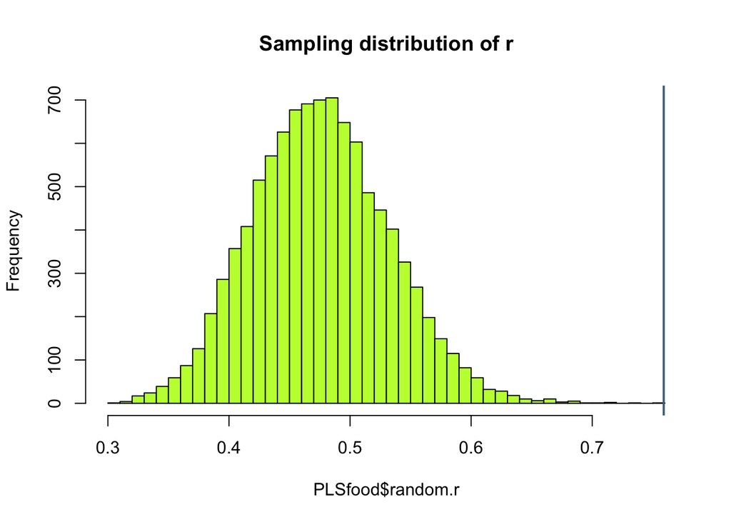

```r
hist(PLSfood$random.r, breaks = 50,
     col = "olivedrab1",
     main = "Sampling distribution of r")
abline(v = PLSfood$r.pls, lwd = 2, col = "skyblue4")
```

Or we might make scatter plots between first PLS scores

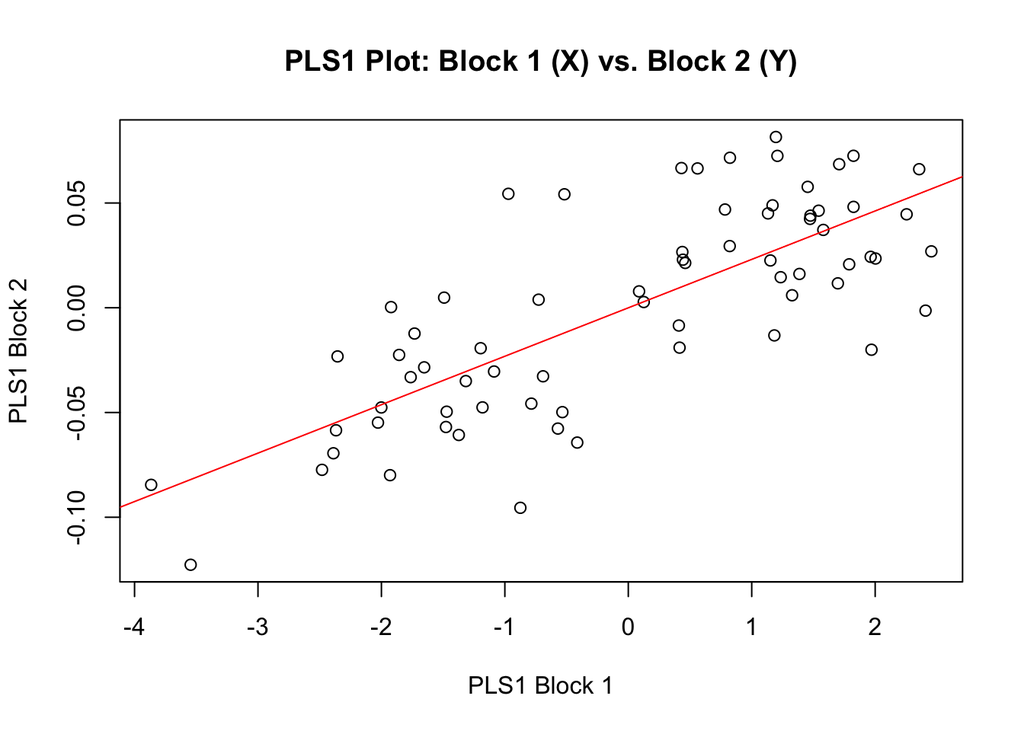

```r
foodPlot <- plot(PLSfood)
```

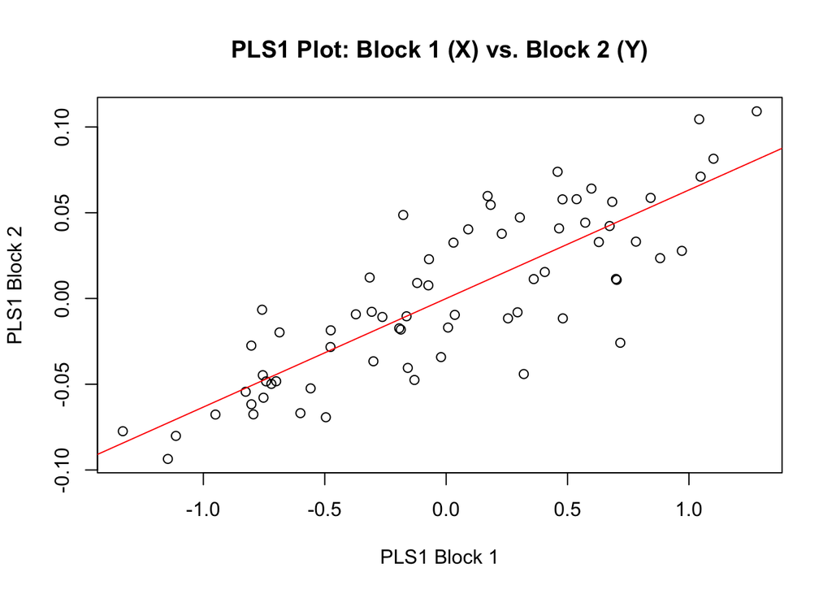

```r
allomPlot <- plot(PLSallometry)
```

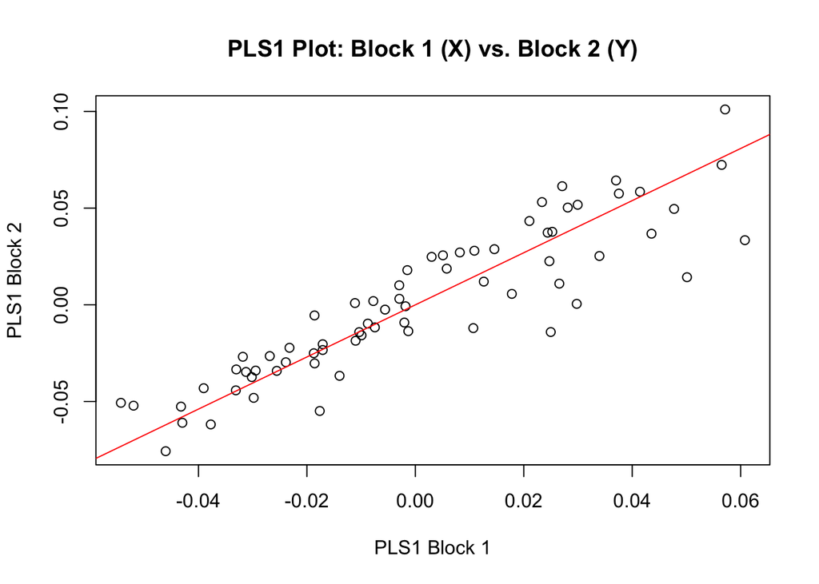

```r
integPlot <- plot(PLSintegration)
```

Each plot above can be explored interactively with `picknplot.shape`.

Finally, we can compare statistically the three PLS effect sizes.

```r
compare.pls(PLSfood,
            PLSallometry,
            PLSintegration)
```

```
##
## Effect sizes
##
##        PLSfood   PLSallometry PLSintegration
##       4.315216       5.566575       5.936474
##
## Effect sizes for pairwise differences in PLS effect size
##
##                 PLSfood PLSallometry PLSintegration
## PLSfood        0.000000    2.3948850      3.0941152
## PLSallometry   2.394885    0.0000000      0.7911531
## PLSintegration 3.094115    0.7911531      0.0000000
##
## P-values
##
##                    PLSfood PLSallometry PLSintegration
## PLSfood        1.000000000   0.01662558    0.001974008
## PLSallometry   0.016625581   1.00000000    0.428854632
## PLSintegration 0.001974008   0.42885463    1.000000000
```

# Generalized Linear Model (GLM)

GLM is discussed in more detail in **Shape Statistics II**. In this module we become a little acquainted with it. The `procD.lm` function wraps the `RRPP::lm.rrpp` function, making sure to format 3D arrays of coordinates in the process.

We will fit two simple models with the same data use in the PLS analyses.

```r
fit.null <- procD.lm(coords ~ 1, data = Y.gpa,
                     iter = 9999)
fit.alt <- procD.lm(coords ~ log(Csize), data = Y.gpa,
                    turbo = FALSE, iter = 9999)
```

Note that there are some options for speeding up analysis with large data sets.

```r
system.time(fit <- procD.lm(coords ~ log(Csize), data = Y.gpa,
                    iter = 9999, turbo = FALSE, Parallel = FALSE))
```

```
##    user  system elapsed
##   0.955   0.040   0.998
```

```r
system.time(fit <- procD.lm(coords ~ log(Csize), data = Y.gpa,
                    iter = 9999, turbo = TRUE, Parallel = FALSE))
```

```
##    user  system elapsed
##   0.590   0.031   0.622
```

```r
system.time(fit <- procD.lm(coords ~ log(Csize), data = Y.gpa,
                    iter = 9999, turbo = FALSE, Parallel = TRUE))
```

```
##    user  system elapsed
##   1.499   1.202   0.730
```

```r
system.time(fit <- procD.lm(coords ~ log(Csize), data = Y.gpa,
                    iter = 9999, turbo = FALSE, Parallel = TRUE))
```

```
##    user  system elapsed
##   1.634   1.080   0.681
```

We will need coefficients in every RRPP permutation (`turbo=FALSE`), so the previous results will suffice.

Let’s look at some of the linear model parts

```r
model.matrix(fit.null)
```

```
##    (Intercept)
## 1            1
## 2            1
## 3            1
## 4            1
## 5            1
## 6            1
## 7            1
## 8            1
## 9            1
## 10           1
## 11           1
## 12           1
## 13           1
## 14           1
```

[output cut: 57 more lines]

```r
coef(fit.null)
```

```
##                   1.X         1.Y       2.X        2.Y        3.X         3.Y
## (Intercept) 0.2415079 -0.07332146 0.2627464 -0.1478185 0.03473031 -0.09093139
##                    4.X       4.Y        5.X        5.Y         6.X          6.Y
## (Intercept) -0.2806804 -0.210035 -0.2896175 -0.1655067 -0.03925596 -0.008809209
##                   7.X          7.Y       8.X       8.Y       9.X        9.Y
## (Intercept) 0.1964961 -0.005244766 0.2489937 0.1166791 0.4406422 0.04415754
##                   10.X       10.Y     11.X      11.Y        12.X     12.Y
## (Intercept) -0.3173787 0.05311804 -0.27118 0.1681822 -0.06589549 0.198903
##                   13.X      13.Y
## (Intercept) -0.1611084 0.1206271
```

```r
fitted(fit.null)
```

```
##          1.X         1.Y       2.X        2.Y        3.X         3.Y        4.X
## 1  0.2415079 -0.07332146 0.2627464 -0.1478185 0.03473031 -0.09093139 -0.2806804
## 2  0.2415079 -0.07332146 0.2627464 -0.1478185 0.03473031 -0.09093139 -0.2806804
## 3  0.2415079 -0.07332146 0.2627464 -0.1478185 0.03473031 -0.09093139 -0.2806804
## 4  0.2415079 -0.07332146 0.2627464 -0.1478185 0.03473031 -0.09093139 -0.2806804
## 5  0.2415079 -0.07332146 0.2627464 -0.1478185 0.03473031 -0.09093139 -0.2806804
## 6  0.2415079 -0.07332146 0.2627464 -0.1478185 0.03473031 -0.09093139 -0.2806804
## 7  0.2415079 -0.07332146 0.2627464 -0.1478185 0.03473031 -0.09093139 -0.2806804
## 8  0.2415079 -0.07332146 0.2627464 -0.1478185 0.03473031 -0.09093139 -0.2806804
## 9  0.2415079 -0.07332146 0.2627464 -0.1478185 0.03473031 -0.09093139 -0.2806804
## 10 0.2415079 -0.07332146 0.2627464 -0.1478185 0.03473031 -0.09093139 -0.2806804
## 11 0.2415079 -0.07332146 0.2627464 -0.1478185 0.03473031 -0.09093139 -0.2806804
## 12 0.2415079 -0.07332146 0.2627464 -0.1478185 0.03473031 -0.09093139 -0.2806804
## 13 0.2415079 -0.07332146 0.2627464 -0.1478185 0.03473031 -0.09093139 -0.2806804
## 14 0.2415079 -0.07332146 0.2627464 -0.1478185 0.03473031 -0.09093139 -0.2806804
```

[output cut: 265 more lines]

```r
resid(fit.null)
```

```
##              1.X           1.Y           2.X           2.Y           3.X
## 1  -0.0076714377 -0.0112686804  4.787549e-03 -0.0105155359 -0.0159243670
## 2  -0.0024541083  0.0255973042 -5.583594e-03 -0.0003739754 -0.0088774220
## 3   0.0055248394  0.0193237877  1.247894e-02  0.0302408157  0.0128669464
## 4   0.0133751928 -0.0048101939  2.929055e-02  0.0035852290  0.0188411368
## 5   0.0071810562  0.0192889357  1.809482e-02 -0.0152961549 -0.0213326034
## 6   0.0046218158 -0.0001880675  9.161718e-03  0.0146200188 -0.0278723158
## 7  -0.0030289091  0.0013273384 -9.151041e-03  0.0140003344 -0.0236397838
## 8   0.0082774048 -0.0052544163  7.453877e-03 -0.0134260478 -0.0154925887
## 9  -0.0004324610  0.0152437354  2.020994e-02  0.0132092682  0.0002835061
## 10 -0.0045322366  0.0056536678 -2.283224e-05  0.0147728784 -0.0249432540
## 11  0.0033329121  0.0180289714  9.864298e-03  0.0171090935 -0.0071753591
## 12 -0.0022583312  0.0162048877 -7.919565e-03 -0.0006470753  0.0130300863
## 13  0.0027252180  0.0038033626  1.339509e-02  0.0102949368 -0.0212187117
## 14 -0.0004586070  0.0026616094 -4.755488e-03  0.0271578623 -0.0099622767
```

[output cut: 405 more lines]

```r
model.matrix(fit.alt)
```

```
##    (Intercept) log(Csize)
## 1            1   1.501023
## 2            1   1.415598
## 3            1   1.709488
## 4            1   1.641995
## 5            1   1.409325
## 6            1   1.631807
## 7            1   1.643086
## 8            1   1.551710
## 9            1   1.635676
## 10           1   1.586874
## 11           1   1.656084
## 12           1   1.476448
## 13           1   1.651565
## 14           1   1.603674
```

[output cut: 55 more lines]

```r
coef(fit.alt)
```

```
##                    1.X        1.Y        2.X         2.Y         3.X
## (Intercept) 0.20280224 -0.1113977 0.18840275 -0.26478242  0.07183187
## log(Csize)  0.02625426  0.0258273 0.05042762  0.07933718 -0.02516617
##                     3.Y         4.X         4.Y         5.X         5.Y
## (Intercept) -0.10382422 -0.25283896 -0.09617182 -0.24909544 -0.04620803
## log(Csize)   0.00874527 -0.01888499 -0.07723395 -0.02748634 -0.08092083
##                     6.X         6.Y        7.X         7.Y        8.X
## (Intercept) -0.15189901 -0.12482067 0.17906920 -0.04202222 0.19738280
## log(Csize)   0.07640631  0.07869113 0.01182072  0.02494632 0.03500789
##                     8.Y        9.X         9.Y       10.X        10.Y
## (Intercept)  0.22277002  0.6224375  0.14209923 -0.2785311 -0.01523022
## log(Csize)  -0.07196199 -0.1233126 -0.06643432 -0.0263505  0.04636095
##                    11.X       11.Y        12.X        12.Y        13.X
## (Intercept) -0.23733900 0.12470788 -0.06325867  0.27081297 -0.22896415
## log(Csize)  -0.02295454 0.02948886 -0.00178857 -0.04877688  0.04602688
##                   13.Y
## (Intercept) 0.04406722
## log(Csize)  0.05193096
```

```r
fitted(fit.alt)
```

```
##          1.X         1.Y       2.X        2.Y        3.X         3.Y        4.X
## 1  0.2422105 -0.07263033 0.2640958 -0.1456955 0.03405687 -0.09069737 -0.2811858
## 2  0.2399677 -0.07483663 0.2597880 -0.1524729 0.03620669 -0.09144443 -0.2795725
## 3  0.2476836 -0.06724624 0.2746082 -0.1291564 0.02881060 -0.08887428 -0.2851226
## 4  0.2459116 -0.06898941 0.2712046 -0.1345112 0.03050915 -0.08946453 -0.2838480
## 5  0.2398030 -0.07499866 0.2594716 -0.1529706 0.03636457 -0.09149930 -0.2794540
## 6  0.2456441 -0.06925254 0.2706909 -0.1353195 0.03076555 -0.08955363 -0.2836556
## 7  0.2459402 -0.06896124 0.2712596 -0.1344246 0.03048170 -0.08945499 -0.2838686
## 8  0.2435412 -0.07132121 0.2666518 -0.1416741 0.03278126 -0.09025409 -0.2821430
## 9  0.2457457 -0.06915260 0.2708860 -0.1350125 0.03066817 -0.08951979 -0.2837287
## 10 0.2444645 -0.07041302 0.2684251 -0.1388843 0.03189632 -0.08994657 -0.2828071
## 11 0.2462815 -0.06862552 0.2719151 -0.1333934 0.03015457 -0.08934132 -0.2841141
## 12 0.2415653 -0.07326505 0.2628565 -0.1476452 0.03467534 -0.09091229 -0.2807217
## 13 0.2461628 -0.06874225 0.2716872 -0.1337519 0.03026831 -0.08938084 -0.2840288
## 14 0.2449055 -0.06997913 0.2692722 -0.1375514 0.03147353 -0.08979965 -0.2831243
```

[output cut: 265 more lines]

```r
resid(fit.alt)
```

```
##              1.X           1.Y           2.X           2.Y           3.X
## 1  -0.0083739914 -0.0119598088  3.438126e-03 -1.263857e-02 -0.0152509301
## 2  -0.0009138876  0.0271124769 -2.625230e-03  4.280384e-03 -0.0103538093
## 3  -0.0006508121  0.0132485681  6.171174e-04  1.157875e-02  0.0187866522
## 4   0.0089715288 -0.0091422431  2.083225e-02 -9.722108e-03  0.0230622939
## 5   0.0088859792  0.0209661323  2.136953e-02 -1.014408e-02 -0.0229668670
## 6   0.0004856331 -0.0042569853  1.217184e-03  2.120978e-03 -0.0239075544
## 7  -0.0074612069 -0.0030328789 -1.766433e-02  6.064695e-04 -0.0193911797
## 8   0.0062440923 -0.0072546619  3.548412e-03 -1.957047e-02 -0.0135435455
## 9  -0.0046702324  0.0110748810  1.207028e-02  4.032382e-04  0.0043456459
## 10 -0.0074887532  0.0027452317 -5.701533e-03  5.838645e-03 -0.0221092683
## 11 -0.0014406579  0.0133330318  6.955084e-04  2.683945e-03 -0.0025996265
## 12 -0.0023156741  0.0161484773 -8.029706e-03 -8.203586e-04  0.0130850527
## 13 -0.0019296956 -0.0007758503  4.454206e-03 -3.771646e-03 -0.0167567178
## 14 -0.0038561935 -0.0006807237 -1.128137e-02  1.689077e-02 -0.0067055008
```

[output cut: 405 more lines]

The coefficients in the alternative model could be tested with the following code.

```r
coef(fit.alt, test = TRUE)
```

```
##
## Linear Model fit with lm.rrpp
##
## Number of observations: 69
## Number of dependent variables: 26
## Data space dimensions: 26
## Sums of Squares and Cross-products: Type I
## Number of permutations: 10000
##
## Statistics (distances) of coefficients with 95 percent confidence intervals,
## effect sizes, and probabilities of exceeding observed values
##           based on
## 10000 random permutations using RRPP
##
##                d.obs  UCL (95%)       Zd Pr(>d)
## log(Csize) 0.2734641 0.09937552 5.119583  1e-04
```

We can also perform ANOVA, e.g.,

```r
anova(fit.null, fit.alt, print.progress = FALSE)
```

```
##
## Analysis of Variance, using Residual Randomization
## Permutation procedure: Randomization of null model residuals
## Number of permutations: 10000
## Estimation method: Ordinary Least Squares
## Effect sizes (Z) based on F distributions
##
##                     ResDf Df     RSS      SS      MS     Rsq      F      Z
## coords ~ 1 (Null)      68  1 0.45759                 0.00000
## coords ~ log(Csize)    67  1 0.35001 0.10758 0.10758 0.23511 20.594 5.3289
## Total                  68    0.45759
##                         P Pr(>F)
## coords ~ 1 (Null)
## coords ~ log(Csize) 1e-04
## Total
```

```r
anova(fit.alt)
```

```
##
## Analysis of Variance, using Residual Randomization
## Permutation procedure: Randomization of null model residuals
## Number of permutations: 10000
## Estimation method: Ordinary Least Squares
## Sums of Squares and Cross-products: Type I
## Effect sizes (Z) based on F distributions
##
##            Df      SS       MS     Rsq      F      Z Pr(>F)
## log(Csize)  1 0.10758 0.107583 0.23511 20.594 5.3289  1e-04 ***
## Residuals  67 0.35001 0.005224 0.76489
## Total      68 0.45759
## ---
## Signif. codes:  0 '***' 0.001 '**' 0.01 '*' 0.05 '.' 0.1 ' ' 1
##
## Call: procD.lm(f1 = coords ~ log(Csize), iter = 9999, turbo = FALSE,
##     data = Y.gpa)
```

Looking at the attributes below, what might also be work exploring?

```r
attributes(fit.alt)
```

```
## $names
##  [1] "aov.table"    "call"         "coefficients" "Y"            "X"
##  [6] "QR"           "fitted"       "residuals"    "Terms"        "term.labels"
## [11] "data"         "call"         "LM"           "ANOVA"        "PermInfo"
## [16] "turbo"        "Models"       "fitted"       "residuals"    "coefficients"
## [21] "GM"
##
## $class
## [1] "procD.lm" "lm.rrpp"
```